# Ilustración regresión lineal: ventas vs gasto financiero

Juan David Ospina Arango Técnicas en Aprendizaje Estadístico Universidad Nacional de Colombia - Sede Medellín

29 de junio de 2019

# Introducción

En este documento se ilustran algunos aspectos de un proceso de regresión lineal. La aplicación tiene que ver con predecir el gasto financiero de las empresas a partir de su nivel de ventas.

# Lectura de los datos

La información que se utilizará son los reportes de ventas y de gasto financiero de las empresas para un año en particular. Esta información es pública y puede ser descargada desde el sitio web de la [Superintendencia de Sociedades](https://www.supersociedades.gov.co/delegatura_aec/estudios_financieros/Paginas/sirem.aspx):

```r
ventas_vs_gastofinanciero<-read.csv("ventas_vs_gastofinanciero.csv",sep=";",
                                    encoding="UTF-8")
```

¿Cuantos subsectores hay en la base de datos?

```r
length(unique(ventas_vs_gastofinanciero$SUBSECTOR))
```

```
## [1] 84
```

¿Cuántos clientes tiene cada sector?

```r
table(ventas_vs_gastofinanciero$SUBSECTOR)
```

```
##
##                                   ACUEDUCTO Y ALCANTARILLADO
##                                                           17
##                                                 AGROQUÍMICOS
##                                                           13
##                                       ALIMENTOS CONCENTRADOS
##                                                           19
##                                                        ARROZ
##                                                            5
##                                                         ASEO
##                                                           11
##                                                  AUTOMOTORES
##                                                          153
##                                                   AVICULTURA
##                                                           32
##                                                       AZÚCAR
##                                                           17
##                                                       BANANO
##                                                           34
##                                                       BANCOS
##                                                            1
##                                          BEBIDAS ALCOHÓLICAS
##                                                            8
##                                       BEBIDAS NO ALCOHÓLICAS
##                                                            7
##                                CACAO, CHOCOLATE Y CONFITERÍA
##                                                           10
##                                        CAJAS DE COMPENSACIÓN
##                                                            6
##                                      CALZADO Y MARROQUINERÍA
##                                                           14
##                                                 CARNES FRÍAS
##                                                           11
##                                                      CEMENTO
##                                                           13
##                                                     CEREALES
##                                                            3
##                                   COMBUSTIBLES Y LUBRICANTES
##                                                           28
##                                             COMERCIO DE CAFÉ
```

[output cut: 114 more lines]

```
##                                                           48
##                                                       TABACO
##                                                            1
##                                                       TELCOS
##                                                           12
##                                                     TEXTILES
##                                                           36
##                                             TRANSPORTE AEREO
##                                                           13
##                                          TRANSPORTE MARÍTIMO
##                                                           25
##                                         TRANSPORTE TERRESTRE
##                                                          130
##                                                       VIDRIO
##                                                            9
```

Esto podría verse mejor como un dataframe:

```r
sectores<-as.data.frame(table(ventas_vs_gastofinanciero$SUBSECTOR))
head(sectores)
```

|  | Var1 | Freq |
| --- | --- | --- |
| 1 | ACUEDUCTO Y ALCANTARILLADO | 17 |
| 2 | AGROQUÍMICOS | 13 |
| 3 | ALIMENTOS CONCENTRADOS | 19 |
| 4 | ARROZ | 5 |
| 5 | ASEO | 11 |
| 6 | AUTOMOTORES | 153 |

Ahora cambiemos los nombres de las variables para mejorar la comprensión del conjunto de datos:

```r
names(sectores)<-c("subsector","cant_clientes")
head(sectores)
```

|  | subsector | cant_clientes |
| --- | --- | --- |
| 1 | ACUEDUCTO Y ALCANTARILLADO | 17 |
| 2 | AGROQUÍMICOS | 13 |
| 3 | ALIMENTOS CONCENTRADOS | 19 |
| 4 | ARROZ | 5 |
| 5 | ASEO | 11 |
| 6 | AUTOMOTORES | 153 |

Ahora veamos los subsectores con más clientes:

```r
sectores[order(sectores$cant_clientes,decreasing=TRUE),]
```

|  | subsector | cant_clientes |
| --- | --- | --- |
| 33 | EDIFICACIONES | 369 |
| 75 | SERVICIOS A EMPRESAS | 303 |
| 76 | SERVICIOS A PERSONAS | 216 |
| 57 | OBRAS DE INFRAESTRUCTURA | 204 |
| 25 | COMERCIO DE VARIEDADES Y VESTUARIO | 163 |
| 40 | FERRETERÍA, MATERIALES DE CONSTRUCCIÓN Y MAQUINARÍA | 155 |
| 6 | AUTOMOTORES | 153 |
| 32 | DISTRIBUIDORES PRODUCTOS CONSUMO MASIVO | 153 |
| 83 | TRANSPORTE TERRESTRE | 130 |
| 50 | IPS | 80 |

[output cut: 74 more lines]

Vamos a escoger dos subsectores y a visualizar la relación entre sus ventas y el gasto financiero:

```r
ids<-ventas_vs_gastofinanciero$SUBSECTOR %in% c("EDIFICACIONES","COMERCIO DE VARIEDADES Y VESTUARIO")
datos_dos_subsectores<-ventas_vs_gastofinanciero[ids,]
```

Ahora grafiquemos los datos con la función *plot()*:

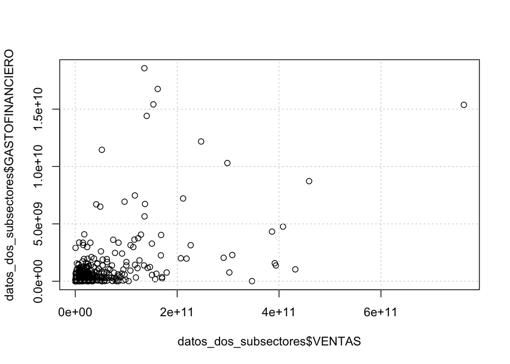

```r
plot(datos_dos_subsectores$VENTAS,datos_dos_subsectores$GASTOFINANCIERO)
grid()
```

Esta gráfica tiene problemas de presentación. El siguiente código muesta algunas ideas para mejorarla:

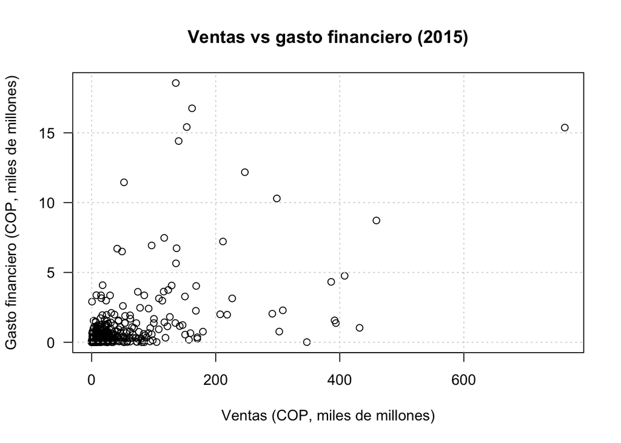

```r
plot(datos_dos_subsectores$VENTAS/10e8,datos_dos_subsectores$GASTOFINANCIERO/10e8,
     xlab="Ventas (COP, miles de millones)",ylab = "Gasto financiero (COP, miles de millones)",main="Ventas vs gasto financiero (2015)",
     las=1)
grid()
```

Veamos que pasa cuando tenemos las ventas en escala logarítmica:

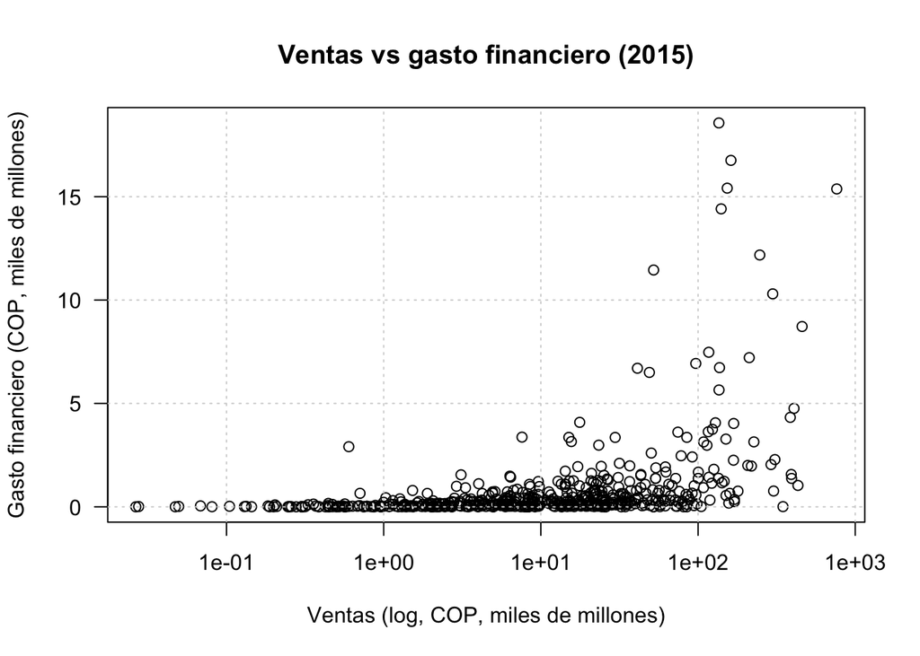

```r
plot(datos_dos_subsectores$VENTAS/10e8,datos_dos_subsectores$GASTOFINANCIERO/10e8,
     xlab="Ventas (log, COP, miles de millones)",ylab = "Gasto financiero (COP, miles de millones)",main="Ventas vs gasto financiero (2015)",
     las=1,log="x")
grid()
```

Veamos que pasa cuando tenemos el gasto financiero en escala logarítmica:

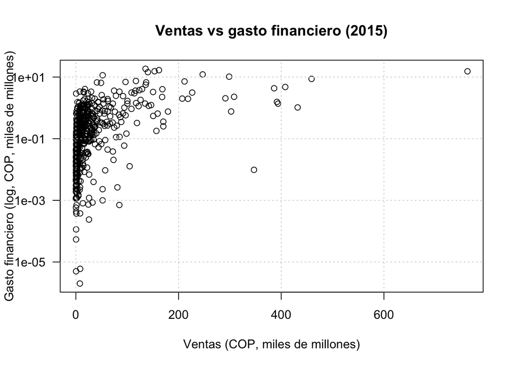

```r
plot(datos_dos_subsectores$VENTAS/10e8,datos_dos_subsectores$GASTOFINANCIERO/10e8,
     xlab="Ventas (COP, miles de millones)",ylab = "Gasto financiero (log, COP, miles de millones)",main="Ventas vs gasto financiero (2015)",
     las=1,log="y")
grid()
```

Veamos que pasa cuando tenemos ambos,las ventas y el gasto financiero, en escala logarítmica:

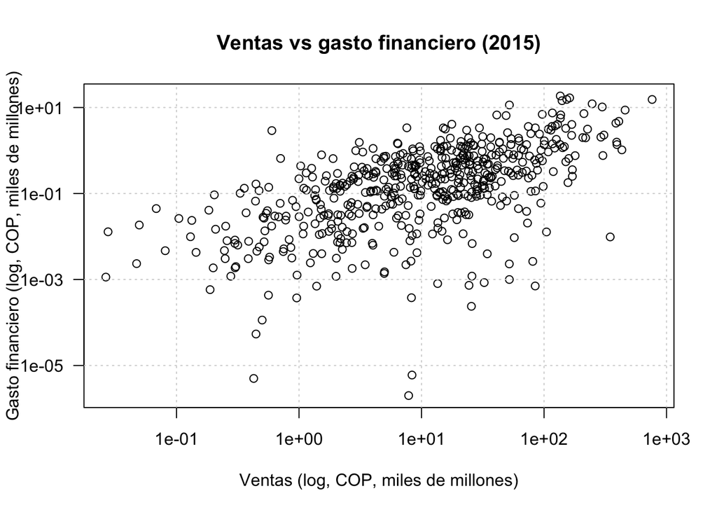

```r
plot(datos_dos_subsectores$VENTAS/10e8,datos_dos_subsectores$GASTOFINANCIERO/10e8,
     xlab="Ventas (log, COP, miles de millones)",ylab = "Gasto financiero (log, COP, miles de millones)",main="Ventas vs gasto financiero (2015)",
     las=1,log="xy")
grid()
```

Aunque ahora pareciera haber una relación lineal, ésta podría no ser la misma para los dos subsectores en cuestión.

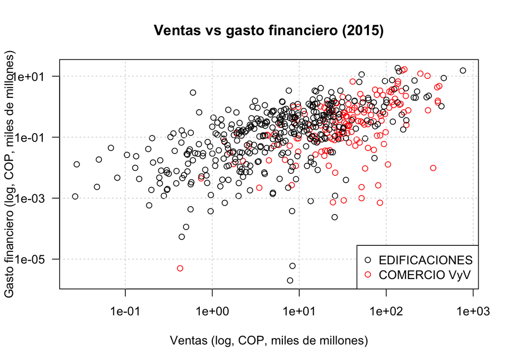

```r
colores<-ifelse(datos_dos_subsectores$SUBSECTOR=="EDIFICACIONES",1,2)
plot(datos_dos_subsectores$VENTAS/10e8,datos_dos_subsectores$GASTOFINANCIERO/10e8,
     xlab="Ventas (log, COP, miles de millones)",ylab = "Gasto financiero (log, COP, miles de millones)",main="Ventas vs gasto financiero (2015)",
     las=1,log="xy",col=colores)
grid()
legend("bottomright",legend=c("EDIFICACIONES","COMERCIO VyV"),col=c(1,2),pch=1)
```

Probemos un modelo lineal para el sector de edificaciones. Para ello transformemos los datos primero:

```r
datos_dos_subsectores_trs<-datos_dos_subsectores
datos_dos_subsectores_trs$VENTAS<-log(datos_dos_subsectores_trs$VENTAS/10e8)
datos_dos_subsectores_trs$GASTOFINANCIERO<-log(datos_dos_subsectores_trs$GASTOFINANCIERO/10e8)
```

Ahora ajustemos un modelo para edificaciones:

```r
modelo_ed_1<-lm(GASTOFINANCIERO~VENTAS,data=datos_dos_subsectores_trs,
                subset=(SUBSECTOR=="EDIFICACIONES"))
summary(modelo_ed_1)
```

```
##
## Call:
## lm(formula = GASTOFINANCIERO ~ VENTAS, data = datos_dos_subsectores_trs,
##     subset = (SUBSECTOR == "EDIFICACIONES"))
##
## Residuals:
##      Min       1Q   Median       3Q      Max
## -11.1541  -0.8871   0.3045   1.2541   5.0192
##
## Coefficients:
##             Estimate Std. Error t value Pr(>|t|)
## (Intercept) -3.55769    0.13670  -26.02   <2e-16 ***
## VENTAS       0.77140    0.05541   13.92   <2e-16 ***
## ---
## Signif. codes:  0 '***' 0.001 '**' 0.01 '*' 0.05 '.' 0.1 ' ' 1
##
## Residual standard error: 1.911 on 367 degrees of freedom
## Multiple R-squared:  0.3456, Adjusted R-squared:  0.3438
## F-statistic: 193.8 on 1 and 367 DF,  p-value: < 2.2e-16
```

Veamos el ajuste del modelo en una gráfica:

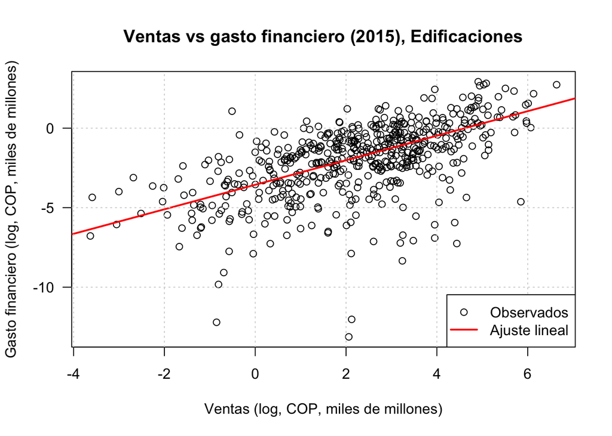

```r
plot(datos_dos_subsectores_trs$VENTAS,datos_dos_subsectores_trs$GASTOFINANCIERO,
     xlab="Ventas (log, COP, miles de millones)",ylab = "Gasto financiero (log, COP, miles de millones)",main="Ventas vs gasto financiero (2015), Edificaciones",
     las=1)
abline(modelo_ed_1,col="red",lwd=2)
grid()
legend("bottomright",legend = c("Observados","Ajuste lineal"),pch=c(1,NA),lty=c(NA,1),
       col=c(1,2),lwd=c(1,2))
```

# Diagnóstico: tarea

Se recomienda investigar y entender el diagnóstico del modelo de regresión lineal para comprender y utilizar las siguientes gráficas.

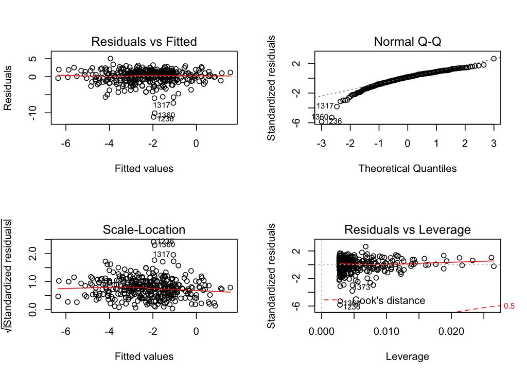

```r
par(mfrow=c(2,2))
plot(modelo_ed_1)
```

# Actividades sugeridas

Se sugieren las siguientes actividades para afianzar las capacidades:

1. Para el modelo para edificaciones retirar los clientes que más se alejan del modelo, reestimar el modelo y observar el cambio en el error residual y en el $R^2$. ¿Para cuántos clientes funciona el modelo? ¿Qué porcentaje de los clientes representan aquellos para los que no funciona el modelo?
2. Estimar un modelo para variedades y vestuario. ¿Qué tan similar es este modelo al de edificaciones?
3. Estime un modelo conjunto para edificaciones y para variedades y vestuario. ¿Qué tan similar es éste a los modelos individuales? ¿Es mejor estimar un modelo conjunto o dos individuales?
4. Predicciones: ¿cuál es el gasto financiero esperado para una empresa del sector de edificaciones con unas ventas de COP $400 mil millones? ¿Cuál es el intervalo de confianza para esta estimación? ¿Cuál sería el valor esperado y el intervalo de confianza para una empresa del sector de variedades y vestuarios con el mismo nivel de ventas?